# Model Validation + Geospacial Graphics

## Monday, June 1

Today we will…

- Group Quiz 9
- New Material:
  - Model Validation
  - Graphics with Geospacial Data (Maps)
- Work Time
  - PA 10: Map it!
  - Final Project Submission

## Final Project Submission

# Model Validation

## How do we tell if a model is “good”?

- There are lots of different metrics to measure model performance!
  - Your choice depends on the type of model and what is “good” for the context
  - Do you only care about predictions? Or more about inference?
- Regression
- Classification (binary outcomes)
- See week 9 slides
- RMSE
- $R^2$
- overall prediction success or failure rate
- sensitivity: true positive rate
- specificity: true negative rater
- many more…

## Overfitting and Underfitting

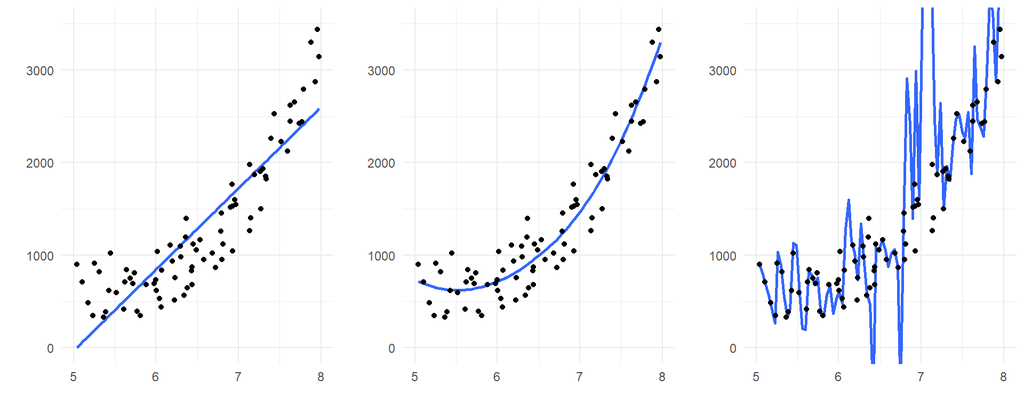

From [Introduction to Statistical Modeling](https://tjfisher19.github.io/introStatModeling/model-validation.html#underfitting-vs.-overfitting-models)

## Big Question for Model Validation

Even if a model is “good” according to our metric with the data we have, how do we know if it will still work well with other data?

[figure not shown]

## Train / Test Split

**Big idea:** Reserve part of your data for testing to get an idea of how the model would do on outside data

1. Split your data into a training and a testing set (typically 80%/20%)
2. Set the testing set aside
3. Do all the model development you want with the training data
4. Fit a final model with the training data
5. Generate predictions from that model with the testing data and calculate your performance metric
6. Compare the testing and training metrics

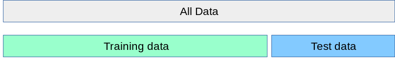

## Comparing Train / Test Performance

- If the model is **over**fit…
  - test performance < training performance
- If the model is **under**fit …
  - test performance > training performance
- If the model is neither over nor underfit …
  - test performance $\approx$ training performance

## $k$-fold Cross Validation

- Iterates over $k$ train / test splits
- Uses all of the data
- Especially useful for model development
  - covariate selection
  - specifying parameters for ML models

## $k$-fold Cross Validation Process

0. Choose a value for $k$
1. Split data into $k$ folds
2. For fold $i$ from 1 … $k$:
   1. Fit model on observations *not* in fold $i$
   2. Generate predictions from this model for the observations **in** fold $i$
   3. Calculate and save performance metric of interest
3. Average the $k$ performance metrics across folds

## $k$-fold Cross Validation Process

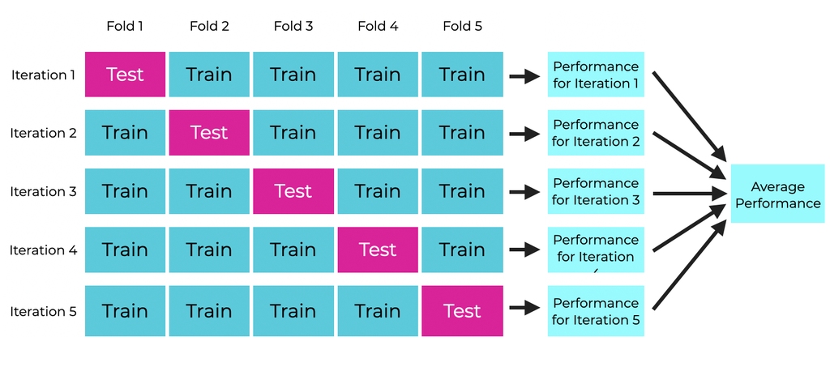

Visualization of 5-fold CV by [Joshua Ebner](https://sharpsight.ai/blog/cross-validation-explained/)

## $k$-fold Cross Validation Process - details

0.Choose a value for $k$

- Typical values are 5 or 10

```r
k <- 5
```

## $k$-fold Cross Validation Process - details

1. Split data into $k$ folds
- Should be approximately the same size
- You *could* just split the data into $k$ groups based on their row number

```r
n <- nrow(ncbirths)

ncbirths <- ncbirths |>
  mutate(fold_cut = cut(1:n, breaks = k, labels = FALSE))
```

- More typical to assign groups randomly

```r
set.seed(394)

ncbirths <- ncbirths |>
  mutate(fold_random = sample(rep_len(1:k, length.out = n),
                       size = n))
```

## $k$-fold Cross Validation Process - details

We implemented 5-fold CV for the model of birth weight on gestation weeks with the NC births data…

```r
cv_r2
```

```
[1] 0.3412554 0.4472941 0.5447437 0.5104462 0.2991063
```

3. Average the $k$ performance metrics across folds

```r
mean(cv_r2)
```

```
[1] 0.4285691
```

The $R^2$ from fitting the model on the full dataset was 0.449, so it appears the model is neither overfitting or underfitting (*maybe* slightly overfitting).

Source: [scikit learn documentation](https://scikit-learn.org/stable/modules/cross_validation.html#cross-validation-evaluating-estimator-performance)

## A first (not ideal) attempt at k-fold CV

```r
# write a function to calculate the R2
r2_calc <- function(obs, pred){

  sse <- sum((obs - pred)^2, na.rm = T)
  sst <- sum((obs - mean(obs, na.rm = T))^2, na.rm = T)

  1 - sse/sst

}
```

```r
cv_r2 <- rep(NA, k)

# for each fold 1-k...
for(x in 1:k){

  # separate fold (test) data
  fold_dat <- ncbirths |>
    filter(fold_random == x)

  # and training data
  train_dat <- ncbirths |>
    filter(fold_random != x)

  # fit model with training data
  it_lm <- lm(weight ~ weeks,
               data = train_dat)

  # generate predictions for the held-out fold data
  fold_preds <- predict(it_lm, newdata = fold_dat)

  # calculate R2 for the held-out fold data and save it
  cv_r2[x] <- r2_calc(obs = fold_dat$weight,
                      pred = fold_preds)

}
```

- Not great!! This only works for the exact data and model that I was working with AND uses for-loops 🫣

## Let’s write a general CV function to make this efficient!

- Inputs:
  - a dataframe
  - formula for the desired model
  - number of folds ($k$)
- Output:
  - vector of $k$ $R^2$ values

**Important**

You may need this function on the final exam…

# Graphics with Geospacial Data (Maps)

## We see geospacial graphics all the time

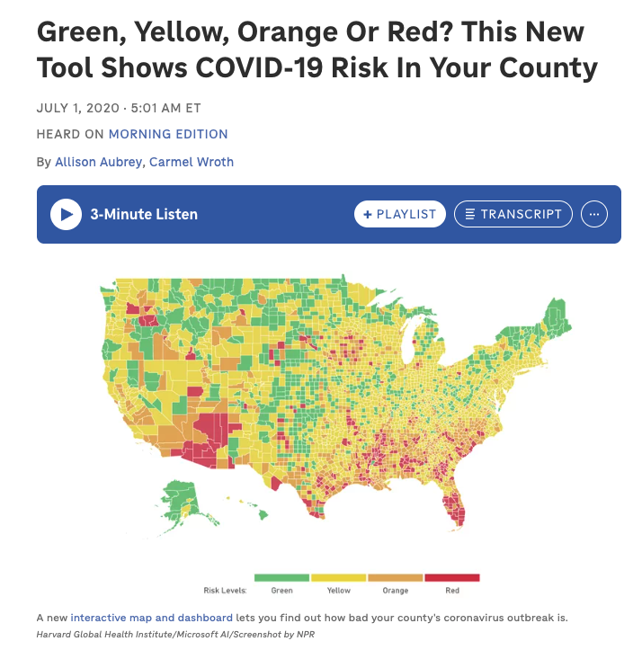

https://www.npr.org/sections/health-shots/2020/07/01/885263658/green-yellow-orange-or-red-this-new-tool-shows-covid-19-risk-in-your-county

Plotting geospacial data can uncover patterns that would be hard to determine through other analyses …

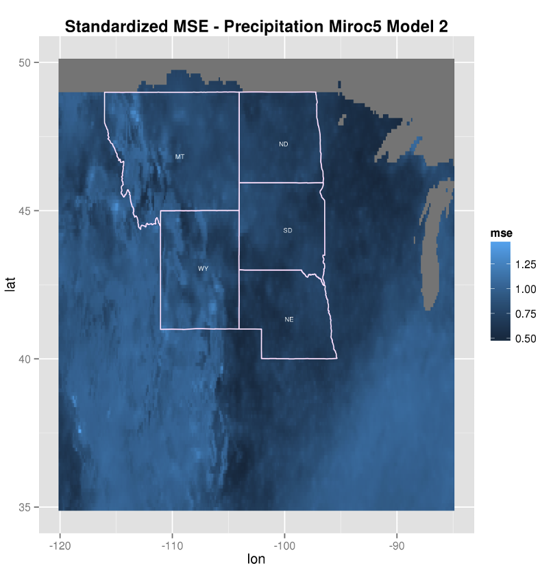

https://hpcf-files.umbc.edu/research/papers/REU2015Team2.pdf

… It can also help make grouping of observations in your analysis clear!

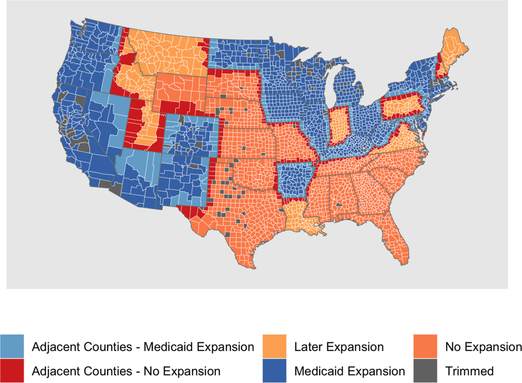

https://pmc.ncbi.nlm.nih.gov/articles/PMC11180987/

## ArcGIS doesn’t get to have all the fun

- There are now many tools in `R` to plot geospacial data
- `maps` / `mapdata` + `geom_polygon()`
  - pros: simplest way to map the US counties / states and world countries
  - cons: doesn’t include all geospacial boundaries you might want!
- [`sf`](https://r-spatial.github.io/sf/)
  - pros: work with any common spacial object (like those used in ArcGIS) plus well maintained and up to date!
  - cons: a bit more of a learning curve to use

## PA 10: Map it!

The best way to learn how to make nice maps with `ggplot` is to just jump in yourself!

[figure not shown]

This image has nothing to do with this PA, it used to and is too fun to remove.

## To do…

- **PA 10: Map it!**
  - Due **Tuesday, 6/2 at 11:59pm**.
- **Lab 9**
  - Due **Tuesday, 6/2 at 11:59pm**.
- **Final Project Report**
  - Due **Friday, 6/5 at 11:59pm**.
- **Course Evaluation**
  - Closes **Friday, 6/5 at 11:59pm**.